# Coordinate systems and maps

# Goals:

1. In the first exercise, you will learn to construct maps with `tmap()` by modifying the provided code. The libraries, data, and initial code is provided below.
2. In the second exercise, you learn to inspect and assess the compatibility of the provided spatial datasets
3. In the third exercise, you
- learn how to extrapolate a missing CRS, and
- define the missing projection in R
4. In the fourth (and optional) exercise, you learn to
- reconcile CRS of your spatial data
- reproject raster and vectors to a shared SRS
5. In the fifth exercise, you create a map of Denmark using online data and
- plot other layers on top of it
- and (optionally) limit your data into an area of interest

#### Required R libraries

We will use the `sf`, `raster`, and `tmap` packages and then a few oldies.

```r
library(sf)
library(raster)
library(tmap)
library(googlesheets4)
library(tidyverse)
```

# Exercise 1 - Fix a map of Denmark

In this exercise you will learn to make a map with `tmap` library, by adding spatial data layers and modifying the arguments that specify their rendering

#### Data sets

We will use two data sets: `elevation` and `counties`. Both originate from the UC Davis global databaset and you can redownload them with `getData()`. (see Week02, Exercise 12) The first one is an elevation raster object for Denmark, and the second one is a spatial dataframe object with polygons representing the 99 Danish municipalities.

#### Existing code

Here is the code to create a new map of Denmark. Your role is to improve this map based on the suggestions below.

```
trying to read file: C:\Users\adela\Documents\RStudio\1_Teaching\cds-spatial\data\DNK_msk_alt.grd
```

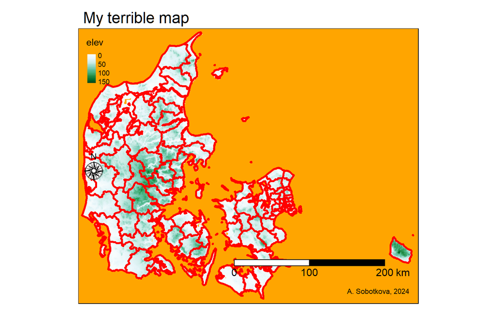

```r
# get elevation
elevation <- raster("../data/DNK_msk_alt.grd")

# get counties
counties <- readRDS("../data/gadm36_DNK_2_sp.rds")


# starting a static map
tm_shape(elevation) + tm_raster(title = "elev", style = "cont", palette = "BuGn") +
    tm_shape(counties) + tm_borders(col = "red", lwd = 3) + tm_scale_bar(breaks = c(0,
    100, 200), text.size = 1) + tm_compass(position = c("LEFT", "center"), type = "rose",
    size = 2) + tm_credits(text = "A. Sobotkova, 2024") + tm_layout(main.title = "My terrible map",
    bg.color = "orange", inner.margins = c(0, 0, 0, 0))
```

## Tasks

1. Change the map title from “My terrible map” to “Denmark municipalities”.
2. Update the map credits with your own name and today’s date.
3. Change the color palette to “-RdYlGn”. (You can also try other palettes from http://colorbrewer2.org/)
4. Put the north arrow in the top right corner of the map or some better position.
5. Improve the legend title by adding the used units (masl).
6. Increase the number of breaks in the scale bar and move it to top right.
7. Change the borders’ color of the municipalities to black. Decrease the line width.
8. Change the background color to some reasonable color of your choice.

## Your solution

```r
# /Start Code/

# /End Code/
```

# Exercise 2 - Create and inspect spatial data

We will use three data sets: `elevation`, `places` and `nitrates`, explore them, and make a map. The first one is an elevation raster object for Denmark you already used above. The second dataset is a list of places you created in week 1. The third is a geochemical dataset from landbrug.dk.

You have already read in the raster, and so now the focus is on the vector data. You need to create these from googlesheet/csv before you can inspect them. Follow the instructions and answer the questions related.

#### Preparation: Create vector data from a csv with LatLong and WKT

Load the two datasets:

- read in the places googlesheet using the `read_sheet()` function (grab it from W01 exercise)
- use read_csv() to grab nitrates.csv fileand use `slice()` function to grab the first 5000 records upon reading it in to reduce its size.

```r
# Load your DK places googlesheet from W01
gs4_deauth()  # if the Gdrive authentication is not working for you

places <- read_sheet("https://docs.google.com/spreadsheets/d/1PlxsPElZML8LZKyXbqdAYeQCDIvDps2McZx1cTVWSzI/edit#gid=1817942479",
    range = "SA2024", col_types = "cccnncnc")


# Load the first 5000 rows in .csv-file and save it as 'nitrates':
nitrates <- read_csv("../data/nitrate.csv") %>%
    slice(1:5000)
```

#### Convert the tabular data into simple feature using their geometry columns

Tabular data contain spatial data, that you can use to convert these tibbles into simple features! Note the lat/long columns in `places` and wkt column in `nitrates`. Inspect these columns and convert the objects to simple feature using the `st_as_sf()` function using the `coords` and the `wkt` arguments respectively!

- take `places`, filter missing coordinates away and then use the `st_as_sf()` function with the `coords` argument to cast into a simple feature `places_sf`
- for `nitrates`, use the `st_as_sf()` function with the `wkt` argument to convert to simple feature `nitrates_sf`.
- use `plot(places_sf$geometry)` and `plot(nitrates_sf$WKT)` to view each simple feature in space.

```r
places_sf <- places %>%
  filter(!is.na(_________)) %>%
  st_as_sf(coords = ____(__________,________))

nitrates_sf <- _______(nitrates, wkt = __________)
```

## Instructions and questions

Type answers to the questions as code comments next to or under the code used

- Display the `nitrates_sf` and `places_sf` objects and view their structure. What can you say about the content of each file?
  - What type of data does it store?
  - How many attributes does it contain?
  - What is its geometry? (points, lines, polygons, surfaces, network)
  - What kind of coordinate system does it use?
- Display the `elevation` object and view its structure. What can you say about the content of this file?
  - What type of data does it store?
  - What is the coordinate system used?
  - How many attributes does it contain?
  - How many dimensions does it have?
  - What is the data resolution?
- Can you plot the files on top of one another? Why?

```
Simple feature collection with 21 features and 6 fields
Geometry type: POINT
Dimension:     XY
Bounding box:  xmin: 8.751724 ymin: 54.85961 xmax: 12.54801 ymax: 57.07828
CRS:           NA
# A tibble: 21 × 7
   Placename     Type    Coord…¹ Descr…² Stars…³ Notes            geometry
   <chr>         <chr>   <chr>   <chr>     <dbl> <chr>             <POINT>
 1 Aalborg       cultur… 57.048… Our La…       3 Adel… (9.913457 57.04826)
 2 Aalborg       cultur… 57.078… Lindho…       4 <NA>   (9.91216 57.07828)
 3 Aarhus        nature  56.121… Balleh…       5 <NA>  (10.22639 56.12122)
 4 Aarhus        nature  56.160… <NA>         NA <NA>  (10.22279 56.16041)
 5 Hobro         Food    56.724… Vebbes…      NA <NA>  (9.821816 56.72437)
 6 Nykøbing Mors nature  56.894… Hankli…       5 <NA>  (8.751724 56.89494)
 7 Viborg        cultur… 56.449… Viborg…      NA <NA>  (9.407927 56.44949)
 8 Aarhus        educat… 56.172… Nobelp…       1 <NA>  (10.20067 56.17244)
 9 Odder         <NA>    56.000… Jens H…      NA <NA>  (10.08233 56.00059)
10 Aarhus        cultur… 56.137… Tivoli…       1 <NA>  (10.19619 56.13738)
# … with 11 more rows, and abbreviated variable names ¹CoordinatesFILLTHIS,
#   ²Description, ³Stars1_5
```

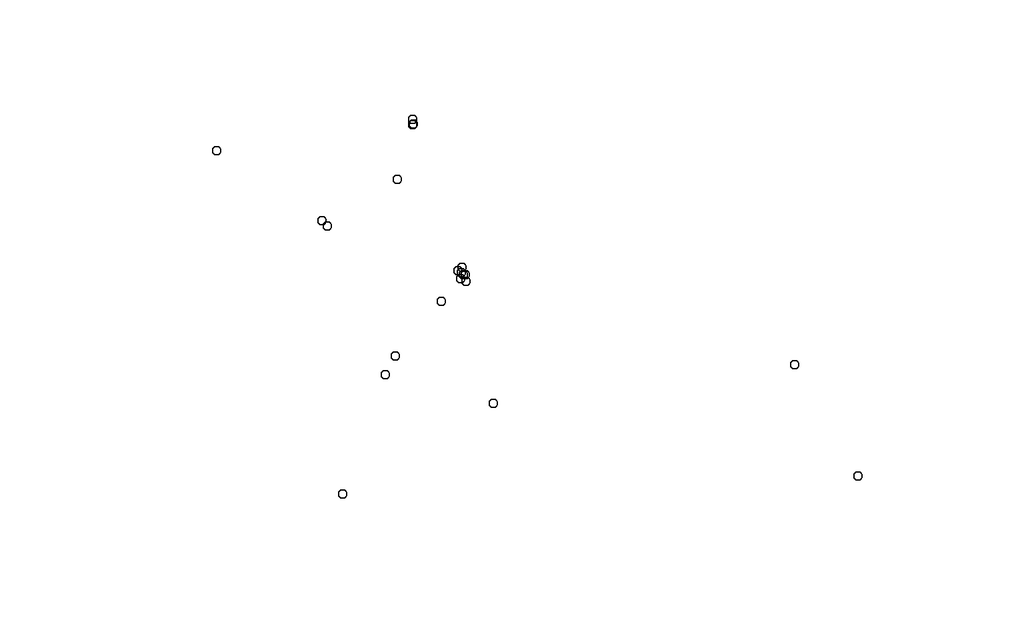

```
Simple feature collection with 5000 features and 18 fields
Geometry type: POINT
Dimension:     XY
Bounding box:  xmin: 444931 ymin: 6054448 xmax: 890918 ymax: 6400414
CRS:           NA
# A tibble: 5,000 × 19
                WKT `Vis data`             DGUnr. Borer…¹ Indtag Analy…² Media…³
            <POINT> <chr>                  <chr>  <chr>    <dbl>   <dbl>   <dbl>
 1 (557818 6377856) http://data.geus.dk/J… 5.  9… http:/…      1       1       2
 2 (508877 6148371) http://data.geus.dk/J… 132. … http:/…     NA       1       2
 3 (701255 6174649) http://data.geus.dk/J… 200. … http:/…      1       1       2
 4 (475687 6208449) http://data.geus.dk/J… 94. 2… http:/…      1       1       2
 5 (707352 6095070) http://data.geus.dk/J… 233. … http:/…      1       1       2
 6 (690302 6134155) http://data.geus.dk/J… 217. … http:/…      1       1       2
 7 (694056 6138665) http://data.geus.dk/J… 217. … http:/…      1       1       2
 8 (649559 6130100) http://data.geus.dk/J… 215. … http:/…      2       6       2
 9 (688049 6151765) http://data.geus.dk/J… 212. … http:/…     NA       1       2
10 (665780 6153530) http://data.geus.dk/J… 211. … http:/…      1       1       2
# … with 4,990 more rows, 12 more variables: `Min. mg/l` <dbl>,
#   `Maks. mg/l` <dbl>, `Indtag topdybde` <dbl>, `Topdybde forklaret` <chr>,
#   Seneste <date>, `Seneste mg/l` <dbl>, objectid <dbl>, symbol_ident <chr>,
#   symbol_size <dbl>, symbol_txt_size <dbl>, txt_search <chr>, rgb <chr>, and
#   abbreviated variable names ¹Borerapport, ²Analyser, ³`Median mg/l`
```

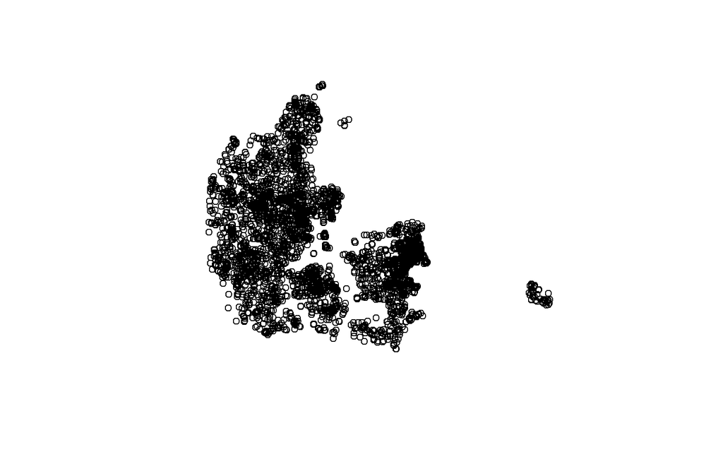

## Your solution and answers

```r
# /Start Code / #


# /End Code/ #
```

# Exercise 3 - Defining coordinate systems

A machine-readable CRS is prerequisite to spatial visualisation and analysis, but not all spatial datasets that float around have its CRS defined. Here you learn to define/specify the coordinate systems for datasets where the CRS is NA/missing/unrecognized by R. You can fix this situation if *YOU* know what the CRS should be.

Look at the coordinates in `places` and `nitrates`again. While both refer to places in Denmark, their formats are different, signalling different CRS. Can you guess what they are?

- `places` contain lat/long columns which you have created on the basis of GoogleMaps which uses `Web Mercator`, or WGS84 CRS. This translates into EPSG 4326.
- `nitrates` contain WKT column with planar coordinates provided by landbrug.dk server. The source server specifies that all data is ETRS89 UTM32N, which corresponds to EPSG 25832.

## Instructions:

- define CRS for each spatial object with `st_set_crs()` using the CRS they are compatible with.
- write the CRS into the name of these defined object in R and write the CRS into the name!

## Your solution and answers

```r
# /Start Code / #

places4326 <- places_sf %>% st_set_crs(_________)

nitrates25832 <- nitrates_sf %>% _________(________)

places4326
nitrates25832
# /End Code/ #
```

```
Simple feature collection with 21 features and 6 fields
Geometry type: POINT
Dimension:     XY
Bounding box:  xmin: 8.751724 ymin: 54.85961 xmax: 12.54801 ymax: 57.07828
Geodetic CRS:  WGS 84
# A tibble: 21 × 7
   Placename     Type    Coord…¹ Descr…² Stars…³ Notes            geometry
 * <chr>         <chr>   <chr>   <chr>     <dbl> <chr>         <POINT [°]>
 1 Aalborg       cultur… 57.048… Our La…       3 Adel… (9.913457 57.04826)
 2 Aalborg       cultur… 57.078… Lindho…       4 <NA>   (9.91216 57.07828)
 3 Aarhus        nature  56.121… Balleh…       5 <NA>  (10.22639 56.12122)
 4 Aarhus        nature  56.160… <NA>         NA <NA>  (10.22279 56.16041)
 5 Hobro         Food    56.724… Vebbes…      NA <NA>  (9.821816 56.72437)
 6 Nykøbing Mors nature  56.894… Hankli…       5 <NA>  (8.751724 56.89494)
 7 Viborg        cultur… 56.449… Viborg…      NA <NA>  (9.407927 56.44949)
 8 Aarhus        educat… 56.172… Nobelp…       1 <NA>  (10.20067 56.17244)
 9 Odder         <NA>    56.000… Jens H…      NA <NA>  (10.08233 56.00059)
10 Aarhus        cultur… 56.137… Tivoli…       1 <NA>  (10.19619 56.13738)
# … with 11 more rows, and abbreviated variable names ¹CoordinatesFILLTHIS,
#   ²Description, ³Stars1_5
```

```
Simple feature collection with 5000 features and 18 fields
Geometry type: POINT
Dimension:     XY
Bounding box:  xmin: 444931 ymin: 6054448 xmax: 890918 ymax: 6400414
Projected CRS: ETRS89 / UTM zone 32N
# A tibble: 5,000 × 19
                WKT `Vis data`             DGUnr. Borer…¹ Indtag Analy…² Media…³
 *      <POINT [m]> <chr>                  <chr>  <chr>    <dbl>   <dbl>   <dbl>
 1 (557818 6377856) http://data.geus.dk/J… 5.  9… http:/…      1       1       2
 2 (508877 6148371) http://data.geus.dk/J… 132. … http:/…     NA       1       2
 3 (701255 6174649) http://data.geus.dk/J… 200. … http:/…      1       1       2
 4 (475687 6208449) http://data.geus.dk/J… 94. 2… http:/…      1       1       2
 5 (707352 6095070) http://data.geus.dk/J… 233. … http:/…      1       1       2
 6 (690302 6134155) http://data.geus.dk/J… 217. … http:/…      1       1       2
 7 (694056 6138665) http://data.geus.dk/J… 217. … http:/…      1       1       2
 8 (649559 6130100) http://data.geus.dk/J… 215. … http:/…      2       6       2
 9 (688049 6151765) http://data.geus.dk/J… 212. … http:/…     NA       1       2
10 (665780 6153530) http://data.geus.dk/J… 211. … http:/…      1       1       2
# … with 4,990 more rows, 12 more variables: `Min. mg/l` <dbl>,
#   `Maks. mg/l` <dbl>, `Indtag topdybde` <dbl>, `Topdybde forklaret` <chr>,
#   Seneste <date>, `Seneste mg/l` <dbl>, objectid <dbl>, symbol_ident <chr>,
#   symbol_size <dbl>, symbol_txt_size <dbl>, txt_search <chr>, rgb <chr>, and
#   abbreviated variable names ¹Borerapport, ²Analyser, ³`Median mg/l`
```

Wonderful, your vector data now have defined spatial metadata. In the next step, reconcile these two CRSs so you can display them in the same map.

# Exercise 4 - Reconciling coordinate systems

Now that you know that coordinate systems differ, make them compatible. You have two final CRS choices. Convert your objects to one or another CRS so that you can display the nitrate samples and DK places over the elevation map of Denmark.

Remember that you use `st_transform()` to reproject vector data, and `projectRaster()` on raster data to change their CRS.

## Instructions

- Option 1: Transform the `nitrates` dataset into the coordinate reference system used in the `places` object.
  - Create a new object `nitrates` with the `places` crs. You can label it `nitrates_####` writing the EPSG out for easy differentiation.
  - Visualize the results using the `plot()` function.
- Option 2: Reproject the `elevation` and `places` data into the coordinate reference system used in the `nitrates` object.
  - Create a new object `elevation_####` with the `nitrates` crs.
  - Visualize the results (`` elevation_####`` together with ``nitrates`)

## Your solution and answers

```r
# /Start Code / #


# /End Code/ #
```

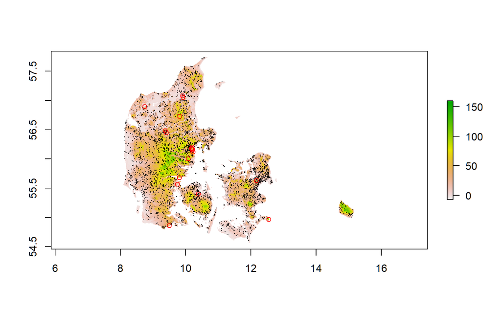

# Exercise 5 - Make your own map of Denmark

Make a handsome map of Denmark! Download data about DK available online and visualize with a scale, a north arrow and source credits. Project the data to EPSG 32632 (another common CRS used in DK: WGS84 UTM32N).

If you want a challenge, do exercise 2 (Week 3) and include a bounding box around the municipality your favorite Danish personality (author/inventor/grandma) lives/lived in. In the title, explain whose birthplace you are putting in focus and include a legend for any environmental background data.

## Hints

*Load elevation and regional boundaries for Denmark using the `getData()` function from the `raster` package.

- Remember that the `getData()` function takes a number of different attributes, plus the country code in a ISO 3-letter format. You can google what it is for Denmark, or use the `getData('ISO3')` function to view it. For an example of how to use the `getData()` function [see this blog](https://www.gis-blog.com/r-raster-data-acquisition/)
- What is the data’s coordinate system? Project it to EPSG 32632
- Choose a reasonable classification if you are using environmental data.
- Create a bounding box over the municipality (see Week03 exercise 2) of your favorite DK person
- Make a clean and legible map of DK and the focus area with `tmap` library following the Exercise no.1 above and the guide [here](https://cran.r-project.org/web/packages/tmap/vignettes/tmap-getstarted.html)

## Your solution

```r
# /Start Code/ #


# /End Code/ #
```

## Refs

Tennekes, Martijn. 2019. Tmap: Thematic Maps. https://CRAN.R-project.org/package=tmap.